# Homework #2: solution

Hugo Lhuillier

08/03/2018

*Remember*: the cleaner and the more documented your code is, the more points you get.

## Exercice 1: playing with data

1. [**easy**] load the `sample.csv` file (careful, it may contain columns name)
2. [**easy**] currently, the `ID` variable is stored as factor. Convert this variable from factors to characters
3. [**trivial**] as in class, clean the `Gender` variable to get rid of `M` and `F`
4. [**easy**] print summary statistics on the current data set
5. [**medium**] create a new variable, `Aneurisms_mean`, which corresponds to the mean aneurism across the four quarters, for each patient
6. [**harder**] plot the distribution of `Aneurisms_mean` for both genders, and then for male and female separately

```r
setwd("/Users/hugolhuillier/Dropbox/Teaching/intro-prog/2017-2018/4-8-r/")
# load the data with headers
d                   <- read.csv(header = TRUE, file = "data/sample.csv")
# convert the ID into characters
d$ID                <- as.character(levels(d$ID))
# transform F into f and M into m
levels(d$Gender)[2] <- "f"
levels(d$Gender)[3] <- "m"
# print some summary statistics
summary(d)
```

```
##       ID            Gender        Group    BloodPressure        Age
##  Length:100         f:39   Control   :30   Min.   : 62.0   Min.   :12.10
##  Class :character   m:61   Treatment1:35   1st Qu.:107.5   1st Qu.:14.78
##  Mode  :character          Treatment2:35   Median :117.5   Median :16.65
##                                            Mean   :118.6   Mean   :16.42
##                                            3rd Qu.:133.0   3rd Qu.:18.30
##                                            Max.   :173.0   Max.   :20.00
##   Aneurisms_q1    Aneurisms_q2    Aneurisms_q3    Aneurisms_q4
##  Min.   : 65.0   Min.   : 80.0   Min.   :105.0   Min.   :116.0
##  1st Qu.:118.0   1st Qu.:131.5   1st Qu.:182.5   1st Qu.:186.8
##  Median :158.0   Median :162.5   Median :217.0   Median :219.0
##  Mean   :158.8   Mean   :168.0   Mean   :219.8   Mean   :217.9
##  3rd Qu.:188.0   3rd Qu.:196.8   3rd Qu.:248.2   3rd Qu.:244.2
##  Max.   :260.0   Max.   :283.0   Max.   :323.0   Max.   :315.0
```

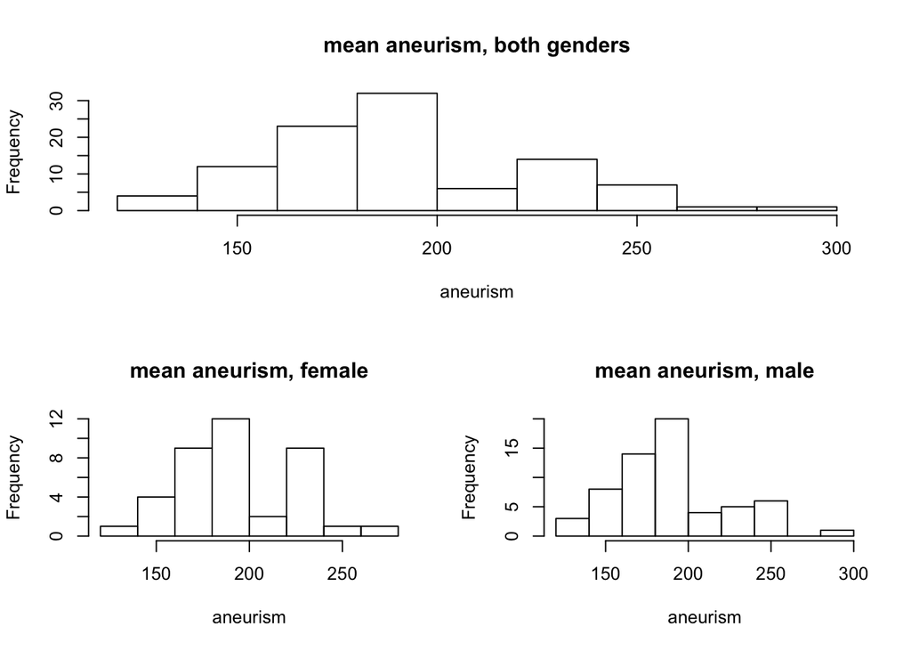

```r
# create a matrix with the aneurism level for each quarter, for each patient
aneurisms_tot       <- matrix(c(d$Aneurisms_q1, d$Aneurisms_q2, d$Aneurisms_q3, d$Aneurisms_q4), ncol = 4)
# compute the mean for each patient across the 4 quarters
d$Aneurisms_mean    <- rowMeans(aneurisms_tot)

# produce the histogram
attach(mtcars)
# create a special layout to combine the 3 histograms
layout(matrix(c(1,1,2,3), 2, 2, byrow = TRUE))
hist(d$Aneurisms_mean, main = "mean aneurism, both genders", xlab = "aneurism")
# plot only the subset with gender = f
hist(d$Aneurisms_mean[d$Gender == "f"], main = "mean aneurism, female", xlab = "aneurism")
# plot only the subset with gender = m
hist(d$Aneurisms_mean[d$Gender == "m"], main = "mean aneurism, male", xlab = "aneurism")
```

## Exercice 2: scaling to $(0,1)$

Write a function `rescale` that takes a vector as input and returns a corresponding vector of values scaled to lie in the range 0 to 1.

```r
scale_unit <- function(x) {
  # rescales x -- a vector -- to lie in the range 0 to 1
  # identifies the lower and upper bound of the vector
  lower_bound <- min(x)
  upper_bound <- max(x)
  # rescale the vector to lie in (0,1)
  scaled_x    <- (x - lower_bound) / (upper_bound - lower_bound)
  return(scaled_x)
}
```

## Exercice 3: testing

Design at least 3 tests – using the `testthat` package – that check whether your `scale_unit` function is working properly.

```r
require("testthat")
# create a vector with a range (1,10) and rescale it to the unit interval
x     <- seq(1,10)
x_new <- scale_unit(x)
# define our tests
test_that("Testing the function scale_unit", {
  expect_true( min(x_new) == 0.0, "minimum = 0")
  expect_true( max(x_new) == 1.0, "maximum = 1")
  expect_true( sd(x_new)  <= sd(x), "variance smaller after rescaling")
})
```

# Exercice 4: scaling to $(a,b)$

Write a function `scale` that takes a vector with a range $(0,1)$ as input and returns a vector of values scaled to lie in the range `a` to `b`.

*Note*: if the original vector does not lie in the $(0,1)$ interval, warn the user that the computation is erroned.

```r
scale <- function(x, a, b) {
  # scales x -- a vector that lies in the (0,1) interval -- to lie in the range a to b
  if (min(x) != 0.0 | max(x) != 1.0) {
    warning("function designed for vectors lying in the unit interval")
  }
  scaled_x    <- x * (b - a) + a
  return(scaled_x)
}
```

# Exercice 5: composition

Write a function that scales an arbitrary vector `x` to a range `a` and `b`, where `a` and `b` are arguments of the function with default value `0` and `1`.

```r
rescale <- function(x, a, b) {
  # rescale an arbitrary vector - x - to an interval (a,b)
  # first, rescale x to lie on the unit interval
  unit        <- scale_unit(x)
  # then, scale unit to the (a,b) range
  scaled_x    <- scale(unit,a,b)
  return(scaled_x)
}
```

# Exercice 6: visual checking

Using randown draws from a $(0,1)$ uniform distrbution, produce a plot that shows why using directly `scale` on a non-unit vector produces the wrong result. **Be creative**.

```r
x        <- 2 * runif(100)
# directly scale x to the (0,10) range - wrong
xwrong   <- scale(x,0,10)
```

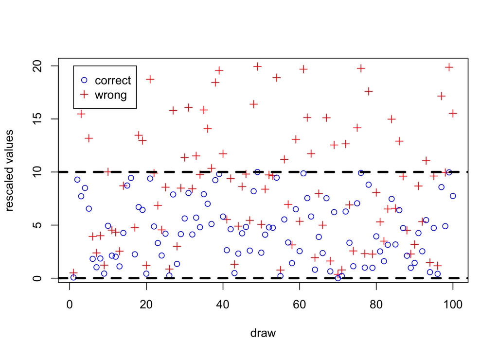

```r
# rescale first x to (0,1), then to (0,10) - correct
xcorrect <- rescale(x,0,10)

plot(xwrong, col = "red", pch = 3, xlab = "draw", ylab = "rescaled values")
# points() add a scatter plot on top of an already existing one
points(xcorrect, col = "blue")
# add horizontal lines at the upper and lower bound of the new interval
abline(h = 0, lwd=3, lty=2)
abline(h = 10, lwd=3, lty=2)
# add a legend, located at the top left corner
legend(1, 20, legend=c("correct", "wrong"), col=c("blue", "red"), pch = c(1,3))
```